# 4 BLISS-RS Formulation

## 4.1 Motivation: From Gradients to Surrogates

BLISS-98 couples the local and system levels through sensitivity derivatives $\partial X^*_{opt} / \partial Z$. Computing these derivatives requires:

1. A converged system analysis (expensive).
2. A local optimization at each BBs (moderately expensive).
3. A sensitivity analysis — typically finite differences or adjoint solves — at the local optimum (often the most expensive step).

These three requirements limit the practical applicability of BLISS-98 in two ways. First, the sensitivity analysis must be repeated each BLISS cycle, making the method computationally intensive for BBs with many variables. Second, because the coupling relies on a *local* linear approximation, the algorithm can be sensitive to the accuracy of the linearization and may stall near saddle points.

BLISS-RS addresses both limitations by replacing the gradient-based coupling with **quadratic response surface surrogates** [1]. The key observations motivating this change are:

- A response surface efficiently *explores the entire design space region* by evaluating the BB at many sample points rather than linearizing around a single point.
- Because BBs in BLISS-RS are optimized off-line for each DOE point independently, those optimizations can proceed in strict parallel — the algorithm becomes a *workfront* that saturates available computing resources.
- The RS coupling eliminates the need for a system sensitivity analysis. The system optimizer reads coupling information directly from the polynomial coefficients.

## 4.2 Local Optimization Formulation

In BLISS-RS, each black box $k$ defines a *synthetic objective function* that aggregates all of its outputs into a single scalar using weighting factors $w$. For given fixed values of $Z$, $Y^*$, and $w$, the $k$-th BB solves:

$$\text{Given:} \quad Z, \; Y^*, \; w
\tag{4.1}$$

$$\text{Find:} \quad X \;\text{(local to BB}_k\text{)}
\tag{4.2}$$

$$\text{Minimize:} \quad F_k = \sum_i w_i \, Y^A_i
\tag{4.3}$$

$$\text{Satisfy:} \quad \{h\} = 0, \quad \{g\} \leq 0, \quad X_L \leq X \leq X_U
\tag{4.4}$$

The term *synthetic* is used because the objective $F_k$ does not represent the actual system objective (range, for example). Instead, it is a proxy that drives each BB toward outputs that are beneficial to the system. The weighting factors $w$ encode the relative importance of each BB output to the overall system objective.

**Note**

**Weighting factor interpretation.** In the supersonic business jet context, the structures BB outputs total weight $W_T$ and aeroelastic twist $\Omega$. Both affect range through the Breguet equation. The weight assigned to each ($w_1$ for $W_T$, $w_2$ for $\Omega$) indicates how strongly minimizing that output will benefit the system objective. The system optimizer determines the appropriate $w$ values automatically as part of its decision variables.

The synthetic objective is evaluated at many points $(Z, Y^*, w)$ by running the local optimization for each DOE sample. The collection of optimal values $F_k^*(Z, Y^*, w)$ forms the data cloud from which the RS is fitted.

## 4.3 System Optimization Formulation

After the RS models are available, the system optimizer solves:

$$\text{Given:} \quad \hat{\boldsymbol{\beta}}_k \;\text{for each BB } k
\tag{4.5}$$

$$\text{Find:} \quad Z, \; Y^*, \; w
\tag{4.6}$$

$$\text{Maximize:} \quad F = \text{Range}(Z, Y^*, w) \;\text{via RS models}
\tag{4.7}$$

$$\text{Satisfy:} \quad \{c\} = Y^A - Y^* = 0, \quad \{g\} \leq 0, \quad \text{side constraints}
\tag{4.8}$$

where $\hat{\boldsymbol{\beta}}_k$ are the regression coefficient vectors for the $k$-th BB’s response surface model. The coupling constraints $\{c\} = 0$ ensure that the value of each coupling variable proposed by the system optimizer ($Y^*$) matches the value that the corresponding BB would actually produce ($Y^A$) given those inputs. In Figure 4.1, coupling constraints are represented as circles where data flow channels from different BBs meet.

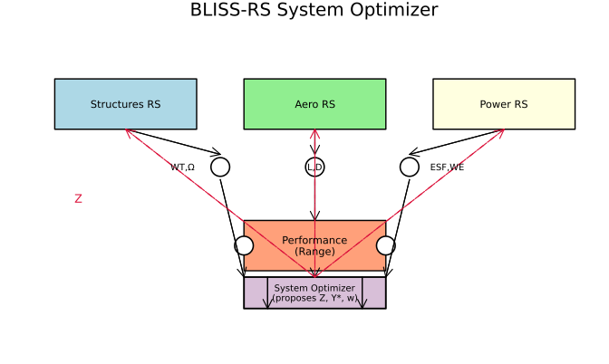

Figure 4.1: BLISS-RS system optimizer data flow. Each coupling constraint (circle) enforces that the output of one BB equals the input to another. The system optimizer proposes Y* and Z; the RS models replace direct BB calls. Reproduced from Altus (2002) Fig. 11.

```julia
p = plot(xlim=(0,12), ylim=(0,10), axis=false, grid=false,
         size=(700,420), title="BLISS-RS System Optimizer")

# BB boxes
bb_data = [(2.0, 7.5, "Structures RS", :lightblue),
           (6.0, 7.5, "Aero RS",       :lightgreen),
           (10.0,7.5, "Power RS",      :lightyellow),
           (6.0, 3.0, "Performance\n(Range)",     :lightsalmon)]

for (x, y, lbl, col) in bb_data
    plot!(Shape([x-1.5,x+1.5,x+1.5,x-1.5],[y-0.8,y-0.8,y+0.8,y+0.8]),
          fill=col, linecolor=:black, lw=1.5, label="")
    annotate!(x, y, text(lbl, 8, :center))
end

# System optimizer box
plot!(Shape([4.5,7.5,7.5,4.5],[1.0,1.0,2.0,2.0]),
      fill=:thistle, linecolor=:black, lw=2.0, label="")
annotate!(6.0, 1.5, text("System Optimizer\n(proposes Z, Y*, w)", 7, :center))

# Coupling constraint circles (where flows cross)
for (cx, cy) in [(4.0, 5.5), (6.0, 5.5), (8.0, 5.5), (4.5, 3.0), (7.5, 3.0)]
    scatter!([cx], [cy], color=:white, markerstrokecolor=:black,
             markerstrokewidth=2, markersize=12, label="")
end
annotate!(3.2, 5.5, text("WT,Ω", 7))
annotate!(6.0, 5.5, text("L,D", 7))
annotate!(8.8, 5.5, text("ESF,WE", 7))

# Arrows (simplified)
for (x1,y1,x2,y2) in [
        (2.0,6.7,4.0,5.9), (6.0,6.7,6.0,5.9), (10.0,6.7,8.0,5.9),
        (4.0,5.1,4.5,2.0), (6.0,5.1,6.0,3.8),  (8.0,5.1,7.5,2.0),
        (6.0,2.2,6.0,2.0), (5.0,2.0,5.0,1.0),  (7.0,2.0,7.0,1.0)]
    plot!([x1,x2],[y1,y2], arrow=true, color=:black, lw=1.2, label="")
end

# Z arrows from optimizer to BBs
for (bx, by) in [(2.0,7.5),(6.0,7.5),(10.0,7.5)]
    plot!([6.0,bx],[2.0,by-0.8], arrow=true, color=:crimson,
          lw=1.2, linestyle=:dash, label="")
end
annotate!(1.0, 4.5, text("Z", 9, :crimson))

p
```

## 4.4 Weighting Factors as System Degrees of Freedom

One of the most important conceptual shifts in BLISS-RS relative to BLISS-98 is the treatment of weighting factors $w$. In BLISS-98, the weighting factors that define each BB’s composite objective function are held fixed — they are determined a priori by the analyst based on engineering judgement about the relative importance of each output.

In BLISS-RS, the weighting factors $w$ are *system-level decision variables*, optimized alongside $Z$ and $Y^*$ by the system optimizer. This means the system optimizer can autonomously determine how much each BB should favour, for example, minimizing weight versus maximizing lift-to-drag.

This autonomy comes at a cost: the design space for the system optimizer grows to include $|Z| + |Y^*| + \sum_k |w_k|$ variables, which increases the complexity of the RS fitting. However, because the system RS is evaluated analytically (not through expensive BB calls), this additional complexity is acceptable.

## 4.5 BLISS-RS Flowchart

Figure 4.2 summarizes the complete algorithm. The critical path of the computation is the BB optimization loop; all other operations are inexpensive polynomial evaluations.

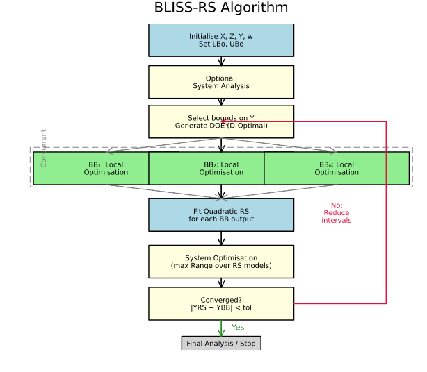

Figure 4.2: BLISS-RS algorithm flowchart. The dashed inner box represents concurrent computations. Reproduced from Altus (2002) Fig. 10.

```julia
p = plot(xlim=(0,12), ylim=(0,14), axis=false, grid=false,
         size=(640,560), title="BLISS-RS Algorithm")

steps = [
    (6.0, 13.3, "Initialise X, Z, Y, w\nSet LBo, UBo", :lightblue),
    (6.0, 11.5, "Optional:\nSystem Analysis", :lightyellow),
    (6.0,  9.8, "Select bounds on Y\nGenerate DOE (D-Optimal)", :lightyellow),
    (2.5,  7.8, "BB₁: Local\nOptimisation", :lightgreen),
    (6.0,  7.8, "BB₂: Local\nOptimisation", :lightgreen),
    (9.5,  7.8, "BBₙ: Local\nOptimisation", :lightgreen),
    (6.0,  5.8, "Fit Quadratic RS\nfor each BB output", :lightblue),
    (6.0,  3.8, "System Optimisation\n(max Range over RS models)", :lightyellow),
    (6.0,  2.0, "Converged?\n|YRS − YBB| < tol", :lightyellow),
]

for (x, y, lbl, col) in steps
    plot!(Shape([x-2.2,x+2.2,x+2.2,x-2.2],[y-0.7,y-0.7,y+0.7,y+0.7]),
          fill=col, linecolor=:black, lw=1.5, label="")
    annotate!(x, y, text(lbl, 7, :center))
end

# Stop box
plot!(Shape([4.8,7.2,7.2,4.8],[0.0,0.0,0.6,0.6]),
      fill=:lightgray, linecolor=:black, lw=1.5, label="")
annotate!(6.0, 0.3, text("Final Analysis / Stop", 7, :center))

# Main arrows
for (y1, y2) in [(12.6,12.2),(10.8,10.5),(9.1,8.5),(7.1,6.5),(5.1,4.5),(3.1,2.7)]
    plot!([6.0,6.0],[y1,y2], arrow=true, color=:black, lw=1.5, label="")
end
# Side BB arrows
plot!([6.0,2.5],[9.1,8.5], arrow=true, color=:gray, lw=1.2, linestyle=:dash, label="")
plot!([6.0,9.5],[9.1,8.5], arrow=true, color=:gray, lw=1.2, linestyle=:dash, label="")
plot!([2.5,6.0],[7.1,6.5], arrow=true, color=:gray, lw=1.2, linestyle=:dash, label="")
plot!([9.5,6.0],[7.1,6.5], arrow=true, color=:gray, lw=1.2, linestyle=:dash, label="")

# Concurrent dashed box
plot!(Shape([0.2,11.8,11.8,0.2],[7.0,7.0,8.7,8.7]),
      fill=nothing, linecolor=:gray50, lw=1.0, linestyle=:dash, label="")
annotate!(0.6, 7.85, text("Concurrent", 7, :gray50, :left, rotation=90))

# "Yes" → Stop, "No" → Reduce RS / loop back
plot!([6.0,6.0],[1.3,0.6], arrow=true, color=:forestgreen, lw=1.5, label="")
annotate!(6.5, 1.0, text("Yes", 8, :forestgreen))
# "No" → Reduce interval and repeat
plot!([8.2,11.0,11.0,6.0],[2.0,2.0,9.8,9.8],
      arrow=true, color=:crimson, lw=1.5, label="")
annotate!(9.5, 5.9, text("No:\nReduce\nintervals", 7, :crimson))

p
```

## 4.6 Comparison: BLISS-98 vs. BLISS-RS

Table 4.1: Comparison of BLISS-98 and BLISS-RS key features

| Feature | BLISS-98 | BLISS-RS |
| --- | --- | --- |
| BB-to-system coupling | Sensitivity derivatives | Quadratic RS surrogates |
| System analysis required per cycle | Yes | No (RS serves this role) |
| Local optimizations per cycle | 1 per BB | $N_S$ per BB (parallelisable) |
| Gradient computation required | Yes | No |
| Handles non-differentiable BBs | No | Yes |
| Prone to local optima | More so | Less so |
| Weighting factors $w$ | Fixed by analyst | Optimised by system level |
| Primary computational cost | Sensitivity analysis | RS generation |

The central tradeoff is that BLISS-RS requires many more BB evaluations per cycle (one per DOE point per BB) compared to BLISS-98 (one per BB). However, because those evaluations are fully concurrent and because the sensitivity analysis step is eliminated, BLISS-RS is expected to achieve better wall-clock performance on multi-processor systems.

[1]

Altus, T. D., “A Response Surface Methodology for Bi-Level Integrated System Synthesis (BLISS),” NASA/CR-2002-211652, NASA Langley Research Center / George Washington University, Hampton, VA, 2002.